# 04 - Catchment

Angus Watters

2023-04-20

# Read in catchments data

```r
catchments        = read_sf(file)
names(catchments) = tolower(names(catchments))
```

These catchments are from VPU 6 which contains 57,642 unique features. The data comes in with each unique feature represented by a multipolygon geometry

| Geometry | Count | Feature IDs |
| --- | --- | --- |
| POLYGON | 0 | 57642 |
| MULTIPOLYGON | 57642 | 57642 |

However in reality, each catchment should only be represented by a single continguous polygon geometry. So what happens if we try to cast all of our MULTIPOLYGONs to POLYGON geometries?

```r
polys <-
  catchments %>%
  st_cast("POLYGON")
```

We end up with *more geometries than we have unique feature IDs*

| Geometry | Count | Feature IDs |
| --- | --- | --- |
| POLYGON | 63319 | 57642 |
| MULTIPOLYGON | 0 | 57642 |

In this case, we have 5677 extra POLYGONs that were created. This means we have a set of smaller polygons that are discontinuous/detached from there bigger “parent” polygons.

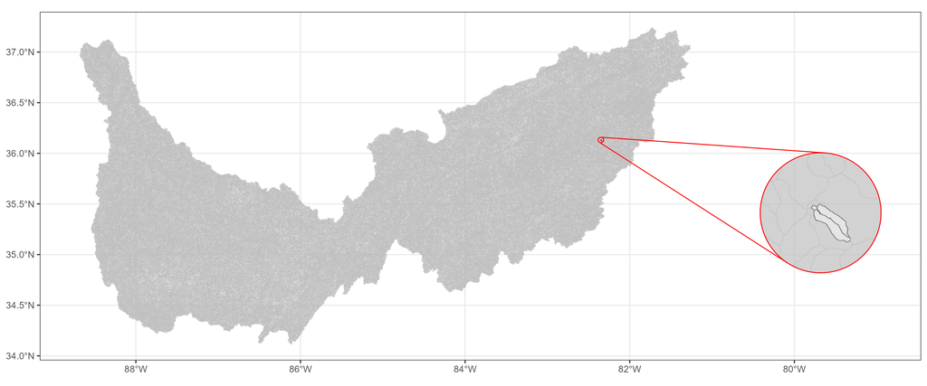

VPU 6 with inset map focused on area of interest

Let’s look at a smaller area of interest to get an example of this multipolygon issue.

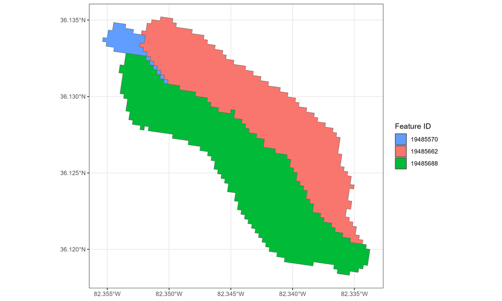

Area of Interest

Looking at the plot above, we can see that that **feature ID 19485570 (blue)** has a set of discontinuous polygons that **should actually be included in the red or green polygons (19485662, 19485688).**

It is not uncommon to see this phenomena throughout the entire NHDPlus dataset. If only there were a function that could clean these geometries…

Introducing the **`clean_geometry2()`** function from **`hydrofab`**! The purpose of **`clean_geometry2()`** is to resolve these problems with the NHDPlus catchment dataset.

# Preprocess: Snap to Grid

Before we do any processing, we’ll need to snap our catchment polygons to a grid with 0.0009 resolution cells.

```r
catchments = lwgeom::st_snap_to_grid(
  st_transform(catchments, 5070),
  size = .0009
  )
```

# 1. Explode the multipart geometries polygons

The first step is to cast all of the NHDPlus multipolygon geomtries into standalone polygons. We then make sure our polygons are still valid, and we generate a count of the number of polygons in each `featureid`. Lastly, we recalculate our areas as now we have broken some catchments into there individual pieces and this means we need to recalculate our areas.

```r
polygons <-
  catchments %>%
  sf::st_cast("POLYGON") %>%
  fast_validity_check() %>%
  dplyr::add_count(featureid) %>%
  dplyr::mutate(
    areasqkm = hydrofab::add_areasqkm(.),
    tmpID    = 1:dplyr::n()
    ) %>%
  nhdplusTools::rename_geometry("geometry")
```

| Geometry | Count | Feature IDs |
| --- | --- | --- |
| POLYGON | 63319 | 57642 |
| MULTIPOLYGON | 0 | 57642 |

Like we saw before, we have **~5000 extra discontiguous/detached polygons** that must be placed in there rightful homes.

Too keep this example at a manageable scale, we are going to filter our catchments just to the problematic example shown earlier.

```r
polygons <- dplyr::filter(polygons, featureid %in% c(19485688, 19485662, 19485570))
# polygons <- dplyr::filter(polygons, featureid %in% c(19750775, 19750735,19750785, 19750793, 19750745))

polygons
```

```
## Simple feature collection with 9 features and 6 fields
## Geometry type: POLYGON
## Dimension:     XY
## Bounding box:  xmin: 1212675 ymin: 1539465 xmax: 1214805 ymax: 1541145
## Projected CRS: NAD83 / Conus Albers
## # A tibble: 9 × 7
##   gridcode featureid sourcefc    areasqkm                   geometry     n tmpID
## *    <int>     <int> <chr>          <dbl>              <POLYGON [m]> <int> <int>
## 1  2770295  19485688 NHDFlowline 0.842    ((1212915 1540455, 121291…     1  3350
## 2  2770349  19485662 NHDFlowline 0.722    ((1214745 1539705, 121465…     1  3399
## 3  2770369  19485570 NHDFlowline 0.000900 ((1213155 1540695, 121318…     7  3419
## 4  2770369  19485570 NHDFlowline 0.000900 ((1213155 1540695, 121312…     7  3420
## 5  2770369  19485570 NHDFlowline 0.000900 ((1213125 1540725, 121309…     7  3421
## 6  2770369  19485570 NHDFlowline 0.000900 ((1213095 1540755, 121306…     7  3422
## 7  2770369  19485570 NHDFlowline 0.000900 ((1213065 1540785, 121303…     7  3423
## 8  2770369  19485570 NHDFlowline 0.000900 ((1213035 1540815, 121300…     7  3424
## 9  2770369  19485570 NHDFlowline 0.0468   ((1213005 1540845, 121285…     7  3425
```

Now we have **3 unique feature IDs and 9 polygons**. Feature ID 19485662 (red) and 19485688 (green) both just a single polygon geometry, while feature ID 19485570 (blue) has 7 separate polygon geometries. The 6 smaller polygons in feature ID 19485570 need to be assigned new homes. The logical choice for these smaller polygons is for them to be dissolved into either feature ID 19485662 (red) and 19485688 (green).

# 2. Separates catchments into main and small parts

Next step is to isolate the polygons that are made up of multiple features. We then dissolve any internal boundaries, recalculate our areas and assign a new temporary ID `(newID)` variable that we will use later on.

```r
# separate polygons with more than 1 feature counts
extra_parts =
  polygons %>%
  dplyr::filter(n != 1) %>%
  rmapshaper::ms_dissolve("featureid", copy_fields = names(.)) %>%
  rmapshaper::ms_explode() %>%
  dplyr::mutate(areasqkm = hydrofab::add_areasqkm(.)) %>%
  dplyr::group_by(featureid) %>%
  dplyr::mutate(
    newID = dplyr::row_number(dplyr::desc(areasqkm))
  ) %>%
  dplyr::ungroup()

extra_parts
```

```
## Simple feature collection with 7 features and 7 fields
## Geometry type: POLYGON
## Dimension:     XY
## Bounding box:  xmin: 1212675 ymin: 1540665 xmax: 1213185 ymax: 1541055
## Projected CRS: NAD83 / Conus Albers
## # A tibble: 7 × 8
##   gridcode     n featureid tmpID sourcefc    areasqkm                   geometry
##      <int> <int>     <int> <int> <chr>          <dbl>              <POLYGON [m]>
## 1  2770369     7  19485570  3419 NHDFlowline 0.000900 ((1213155 1540695, 121315…
## 2  2770369     7  19485570  3419 NHDFlowline 0.000900 ((1213155 1540695, 121315…
## 3  2770369     7  19485570  3419 NHDFlowline 0.000900 ((1213125 1540725, 121312…
## 4  2770369     7  19485570  3419 NHDFlowline 0.000900 ((1213095 1540755, 121309…
## 5  2770369     7  19485570  3419 NHDFlowline 0.000900 ((1213065 1540785, 121306…
## 6  2770369     7  19485570  3419 NHDFlowline 0.000900 ((1213035 1540815, 121303…
## 7  2770369     7  19485570  3419 NHDFlowline 0.0468   ((1213005 1540845, 121300…
## # ℹ 1 more variable: newID <int>
```

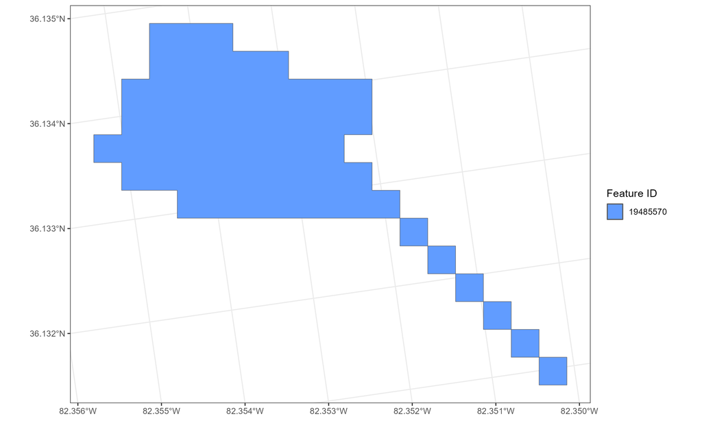

Problematic Catchment Geometries

Now we have our multipolygon catchments that are causing issues. The figure above shows the geometry of the problematic catchment.

Our next step is to split these multipolygon catchments into there main and small parts. The main parts will join the rest of the single polygon catchments, while the smaller parts will be left behind so that they can reassigned to a another catchment such that all catchments in our final dataset are single continuous polygons.

# 3. Extract the biggest parts by area for each catchment, adds them to the rest of the valid polygons

Next, we get the biggest polygon by area from our multipolygon feature (`main_parts`). This leaves us with the main, big catchment area for all of our problem catchments. In our case, this is just a single polygon.

```r
# get the biggest parts by area in each catchment and bind with rest of good_to_go catchments
main_parts <-
  extra_parts %>%
  dplyr::group_by(featureid) %>%
  dplyr::slice_max(areasqkm, with_ties = FALSE) %>%
  dplyr::ungroup()

main_parts
```

```
## Simple feature collection with 1 feature and 7 fields
## Geometry type: POLYGON
## Dimension:     XY
## Bounding box:  xmin: 1212675 ymin: 1540845 xmax: 1213005 ymax: 1541055
## Projected CRS: NAD83 / Conus Albers
## # A tibble: 1 × 8
##   gridcode     n featureid tmpID sourcefc    areasqkm                   geometry
##      <int> <int>     <int> <int> <chr>          <dbl>              <POLYGON [m]>
## 1  2770369     7  19485570  3419 NHDFlowline   0.0468 ((1213005 1540845, 121300…
## # ℹ 1 more variable: newID <int>
```

# 4. Extract the small polygons

We’ll find the small polygons by filtering down our `extra_parts` to the parts that are not in the `main_parts` dataset. We are left with 6 small, discontiguous polygons.

```r
small_parts <-
  extra_parts %>%
  # group_by(featureid) %>%
  dplyr::filter(newID != main_parts$newID) %>%
  rmapshaper::ms_dissolve("featureid", copy_fields = names(.)) %>%
  rmapshaper::ms_explode() %>%
  dplyr::mutate(
    areasqkm = hydrofab::add_areasqkm(.),
    newID    = 1:dplyr::n()
    ) %>%
  dplyr::select(newID)

small_parts
```

```
## Simple feature collection with 6 features and 1 field
## Geometry type: POLYGON
## Dimension:     XY
## Bounding box:  xmin: 1213005 ymin: 1540665 xmax: 1213185 ymax: 1540845
## Projected CRS: NAD83 / Conus Albers
## # A tibble: 6 × 2
##   newID                                                                 geometry
##   <int>                                                            <POLYGON [m]>
## 1     1 ((1213155 1540695, 1213155 1540665, 1213185 1540665, 1213185 1540695, 1…
## 2     2 ((1213155 1540695, 1213155 1540725, 1213125 1540725, 1213125 1540695, 1…
## 3     3 ((1213125 1540725, 1213125 1540755, 1213095 1540755, 1213095 1540725, 1…
## 4     4 ((1213095 1540755, 1213095 1540785, 1213065 1540785, 1213065 1540755, 1…
## 5     5 ((1213065 1540785, 1213065 1540815, 1213035 1540815, 1213035 1540785, 1…
## 6     6 ((1213035 1540815, 1213035 1540845, 1213005 1540845, 1213005 1540815, 1…
```

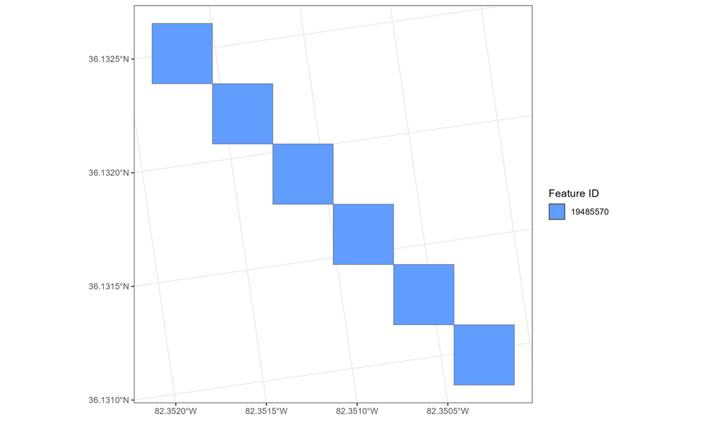

Discontinuous small geometries

Then lets bind our `main_parts` polygons with the rest of the single polygon features in our original `polygons` dataset. This gives us a complete set of the main catchment polygons.

```r
main_parts <-  bind_rows(main_parts, filter(polygons, n == 1))

main_parts
```

```
## Simple feature collection with 3 features and 7 fields
## Geometry type: POLYGON
## Dimension:     XY
## Bounding box:  xmin: 1212675 ymin: 1539465 xmax: 1214805 ymax: 1541145
## Projected CRS: NAD83 / Conus Albers
## # A tibble: 3 × 8
##   gridcode     n featureid tmpID sourcefc    areasqkm                   geometry
## *    <int> <int>     <int> <int> <chr>          <dbl>              <POLYGON [m]>
## 1  2770369     7  19485570  3419 NHDFlowline   0.0468 ((1213005 1540845, 121300…
## 2  2770295     1  19485688  3350 NHDFlowline   0.842  ((1212915 1540455, 121291…
## 3  2770349     1  19485662  3399 NHDFlowline   0.722  ((1214745 1539705, 121465…
## # ℹ 1 more variable: newID <int>
```

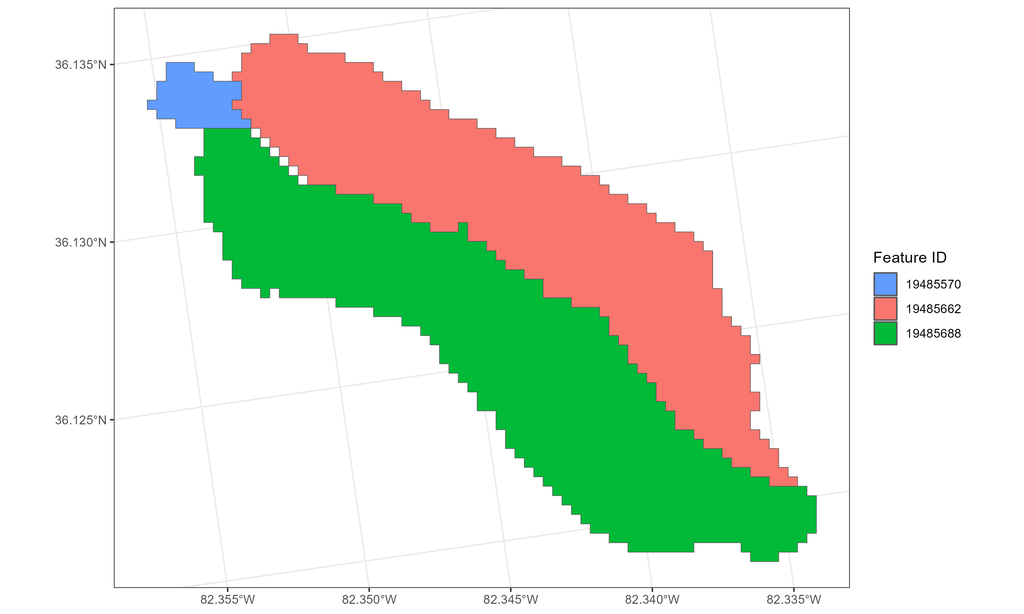

Main catchment geometries after removing small discontinuous geometries

To summarize where we are at. We have 2 groups of data. The `main_parts` group which is our large polygon geometries, and the `small_parts` group, which contains all small, discontinuous polygons that need to be rejoined into an appropriate catchment in our `main_parts` dataset.

We now have 2 datasets:

1. `main_parts`, containing all the primary catchment geometries,
2. `small_parts`, containing all the small, discontiguous polygons that need reassignment

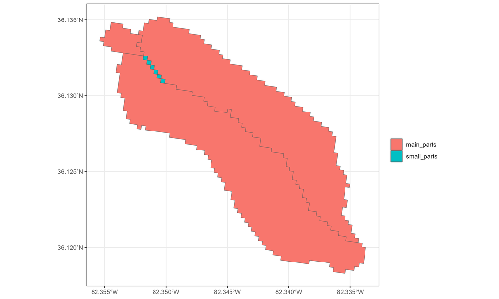

Catchments seperated into main (red) and secondary (blue) parts

Now we need to find new homes for all the small polygons in `small_parts`

# 5. Polygon reassignment

We use the **longest shared border** as the rule for deciding which `main_parts` polygon our `small_parts` should dissolve into.

To do this we first find the geometries from `main_parts` that intersect with `small_parts`, we then extract LINESTRING geometries from the intersections.

```r
# get the intersection between big parts and small parts and pull out the LINESTRINGs
out =
  small_parts %>%
  sf::st_intersection(sf::st_make_valid(main_parts)) %>%
  sf::st_collection_extract("LINESTRING")

out
```

```
## Simple feature collection with 12 features and 8 fields
## Geometry type: MULTILINESTRING
## Dimension:     XY
## Bounding box:  xmin: 1213005 ymin: 1540665 xmax: 1213185 ymax: 1540845
## Projected CRS: NAD83 / Conus Albers
## # A tibble: 12 × 9
##    newID gridcode     n featureid tmpID sourcefc    areasqkm newID.1
##    <int>    <int> <int>     <int> <int> <chr>          <dbl>   <int>
##  1     1  2770295     1  19485688  3350 NHDFlowline    0.842      NA
##  2     2  2770295     1  19485688  3350 NHDFlowline    0.842      NA
##  3     3  2770295     1  19485688  3350 NHDFlowline    0.842      NA
##  4     4  2770295     1  19485688  3350 NHDFlowline    0.842      NA
##  5     5  2770295     1  19485688  3350 NHDFlowline    0.842      NA
##  6     6  2770295     1  19485688  3350 NHDFlowline    0.842      NA
##  7     1  2770349     1  19485662  3399 NHDFlowline    0.722      NA
##  8     2  2770349     1  19485662  3399 NHDFlowline    0.722      NA
##  9     3  2770349     1  19485662  3399 NHDFlowline    0.722      NA
## 10     4  2770349     1  19485662  3399 NHDFlowline    0.722      NA
## 11     5  2770349     1  19485662  3399 NHDFlowline    0.722      NA
## 12     6  2770349     1  19485662  3399 NHDFlowline    0.722      NA
## # ℹ 1 more variable: geometry <MULTILINESTRING [m]>
```

We then place the small polygons into the catchment that they share the longest border with

```r
# calculate linestring lengths and keep the longest one
ints =
  out %>%
  dplyr::mutate(l = sf::st_length(.)) %>%
  dplyr::group_by(.data$newID) %>%
  dplyr::slice_max(.data$l, with_ties = FALSE) %>%
  dplyr::ungroup()

ints
```

```
## Simple feature collection with 6 features and 9 fields
## Geometry type: MULTILINESTRING
## Dimension:     XY
## Bounding box:  xmin: 1213005 ymin: 1540665 xmax: 1213185 ymax: 1540845
## Projected CRS: NAD83 / Conus Albers
## # A tibble: 6 × 10
##   newID gridcode     n featureid tmpID sourcefc    areasqkm newID.1
##   <int>    <int> <int>     <int> <int> <chr>          <dbl>   <int>
## 1     1  2770295     1  19485688  3350 NHDFlowline    0.842      NA
## 2     2  2770295     1  19485688  3350 NHDFlowline    0.842      NA
## 3     3  2770295     1  19485688  3350 NHDFlowline    0.842      NA
## 4     4  2770295     1  19485688  3350 NHDFlowline    0.842      NA
## 5     5  2770295     1  19485688  3350 NHDFlowline    0.842      NA
## 6     6  2770295     1  19485688  3350 NHDFlowline    0.842      NA
## # ℹ 2 more variables: geometry <MULTILINESTRING [m]>, l [m]
```

This provides the `featureid` of the `main_parts` polygon that shares the longest border with the `small_parts` polygons, and thus identifying the catchment that the `small_parts` polygons should dissolve into.

# 6. Dissolves `small_parts` into `main_parts`

We can now join the `small_parts` polygons, with the `ints` data to get the `featureid` of the catchments that share the longest border with `small_parts`. Then we bind this data back with `main_parts` and do a final union on the `featureid` column in our data.

```r
# right join small polygons with intersection data by newID to get featureids to eventually union on
tj <-
  small_parts %>%
  dplyr::right_join(
    dplyr::select(sf::st_drop_geometry(ints), featureid, newID),
    by = "newID"
    ) %>%
  dplyr::bind_rows(main_parts) %>%
  dplyr::select(-areasqkm, -tmpID, -newID) %>%
  dplyr::group_by(featureid) %>%
  dplyr::mutate(n = dplyr::n()) %>%
  dplyr::ungroup() %>%
  nhdplusTools::rename_geometry("geometry")

# Do a final union of all multipolygon geometries
# and bind these rectified catchments back with the already correct catchment polygons
in_cat <-
  hydrofab::union_polygons(
    dplyr::filter(tj, .data$n > 1),
    "featureid"
  ) %>%
  dplyr::bind_rows(
    dplyr::select(
      dplyr::filter(tj, .data$n == 1),
      "featureid")
  ) %>%
  dplyr::mutate(tmpID = 1:dplyr::n()) %>%
  fast_validity_check()
```

[figure not shown]

Final unionified catchment geometries